# Plotting in R

Joseph Crispell

20 May 2018

## Why plot?

Plotting is important because it allows us to quickly see our data - often allowing us to check our expectations. Also plots are much easier to intepret than tables.

I’ve created an example dataset “BadgerInformation.csv”. We’ll be working with these data in this tutorial.

## Reading in data

The data is in a `csv` file. CSV stands for Comma Separated Values, each value in each column is separated by a comma and rows are on new lines. Lets read in the “BadgerInformation.csv” file:

```r
badgerInfo <- read.table(
  file="C:/Users/Joseph Crisp/Dropbox/SummerStudents/BadgerInformation.csv",
  header=TRUE,
  sep=",")
```

We used the `read.table()` function. We provided three inputs for the `read.table()` function:

1. `file` - full path to the file we want to read the table from
2. `header` - we told the `read.table()` function the table has column titles
3. `sep` - we told the `read.table()` function that the value separator in the file is a comma

### Exercise

Read in the “BadgerInformation.csv” using the code above. You’ll need to change the input for the `file` parameter.

## A `data.frame`

We used the `read.table()` function to read the “BadgerInformation.csv” file and we stored the output from `read.table()` in a variable called “badgerInfo”.

We can use the `head()` function to have a quick look at the table:

```r
head(badgerInfo)
```

```
##      Weight    Length    Sex
## 1 19.300824 141.87653   Male
## 2  1.781973  13.98983 Female
## 3  6.989023  59.70055 Female
## 4 11.953651 101.88953 Female
## 5 18.539776 169.97790   Male
## 6 17.619494 155.51552   Male
```

We used the function `head()`. `head()` is a function that will by default print the first 6 rows of a `data.frame`. `data.frame`s in R provide a means of storing a table, with rows and columns. `badgerInfo` is a table with:

```r
dim(badgerInfo)
```

```
## [1] 100   3
```

The `dim()` function will tell us how many rows (100) and columns (3) are in the `data.frame` (`badgerInfo`) we provide it with.

### Exercise

Create a function that mimics `dim()`. It will tell you how many rows and columns a table has. Hint: you could use the `nrow()` function.

## Accessing data in a `data.frame`

The data in a `data.frame` can be accessed by using row and column numbers. For example if I want the value in the 2nd column of the 5th row I would use:

```r
badgerInfo[5, 2]
```

```
## [1] 169.9779
```

So in general, to get a value from a table we use: `tableName[rowNumber, columnNumber]`.

What if we wanted all of the values in a row or column? We can get all the values in the 2nd column using:

```r
head(badgerInfo[,2])
```

```
## [1] 141.87653  13.98983  59.70055 101.88953 169.97790 155.51552
```

### Exercises

How would I get the value in the 1st column of the 3rd row? How would I get all the values in the 34th row?

## Plotting data

So now we have a table with some data, and we know how to access the data in the table, lets get plotting. First lets see what the weights of the badgers look like:

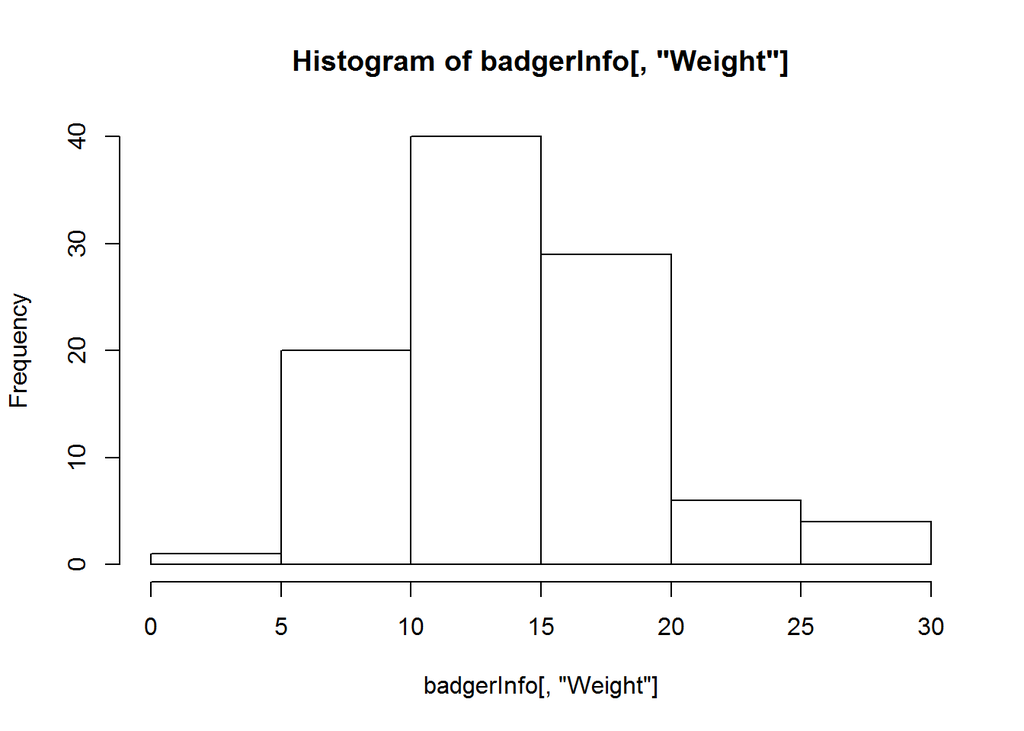

```r
hist(badgerInfo[, "Weight"])
```

The `hist()` function will plot any set of numbers as a histogram - here we gave the `hist()` function the badger weights (we sneakily used the columns name “Weight” as its index).

We can make the plot look a lot better by adding some titles:

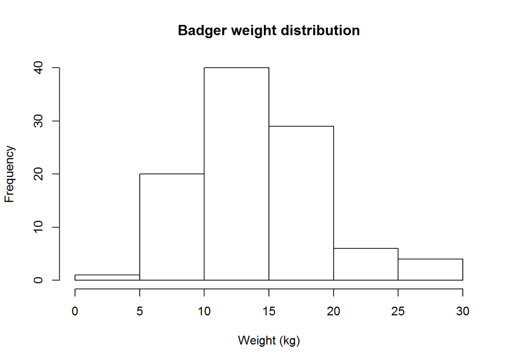

```r
hist(badgerInfo[, "Weight"],
     main="Badger weight distribution",
     xlab="Weight (kg)")
```

How does a badgers weight relate to its length? We can make the plot look a lot better by adding some titles:

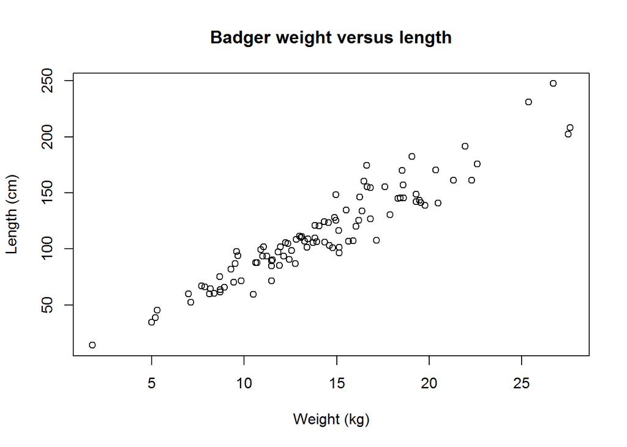

```r
plot(x=badgerInfo[, "Weight"], y=badgerInfo[, "Length"],
     main="Badger weight versus length",
     xlab="Weight (kg)",
     ylab="Length (cm)")
```

Lastly, how does the badger’s sex relate to their weights?

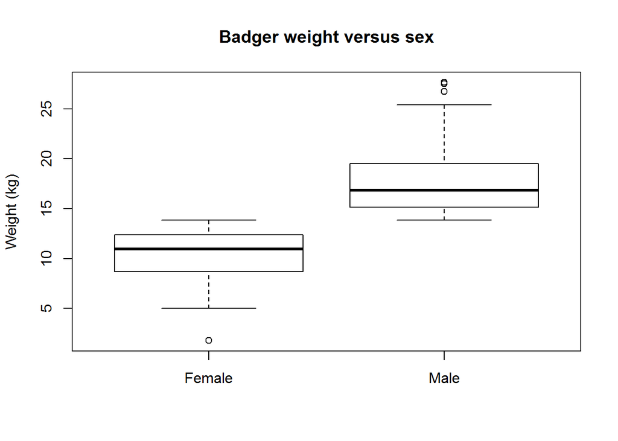

```r
boxplot(badgerInfo[, "Weight"] ~ badgerInfo[, "Sex"],
     main="Badger weight versus sex",
     ylab="Weight (kg)")
```

The `boxplot()` takes its data in the form of a formula: `response ~ explanatory`. Where the explanatory data is the data that we are trying to used to explain the variation we observed in the response data.

### Exercises

Plot a histogram of the badger lengths. Plot a boxplot to see whether there is a relationship between the badger’s length and their sex. Plot the badgers lengths against their lengths using the same code as above but colour the points red and make points be shaped like triangles.

## Learning more

We have very quickly created a few different plots. We used the plots to have a look at some data we had about badgers. By plotting data we were able to see, though we probably expected it, that heavy badgers were longer. Also we found that female badgers were lighter.

Plotting the provides an easy and quick way to see what’s going on with our data. To learn a bit more, there are loads of tutorials available online showing you how to make some amazing plots. Here are a few to get started with:

- https://www.statmethods.net/graphs/creating.html
- https://www.datamentor.io/r-programming/plot-function
- https://www.harding.edu/fmccown/r/